# 均值移动图像分割

## 实验目的

试自行拍摄一幅教学楼外立面图像，并使用均值移动的方法对该图像进行分割。

## 实验环境

- OpenCV
- NumPy
- MatPlotLib

## 实验原理

均值移动（Mean Shift）是一种无监督的聚类算法，常用于图像分割。其核心思想是通过在特征空间中对数据点进行密度估计和迭代更新，寻找密度较高区域的中心（模式）。在图像分割中，均值移动方法将图像的像素值（包括颜色信息和空间坐标）映射到高维特征空间，通过不断更新每个像素所在的特征向量，使得特征向量逐渐靠近相应的密度峰值，进而完成分割。

### 数学模型

均值移动算法可以通过核密度估计的方式进行建模。假设在特征空间中有一个点 $x_i$，其密度函数 $f(x)$ 通过核函数 $\phi(x)$ 表示为：

$$ f(x) = \frac{1}{n h^d} \sum_{i=1}^{n} \phi \left( \frac{x - x_i}{h} \right) $$

其中：

- $n$ 是样本点的数量，
- $x_i$ 是特征空间中的数据点，
- $h$ 是带宽参数，控制核函数的窗口大小，
- $d$ 是特征空间的维度。

均值移动的核心步骤是计算均值移动向量，其表达式为：

$$ m(x) = \frac{\sum_{i=1}^{n} x_i \phi \left( \frac{x - x_i}{h} \right)}{\sum_{i=1}^{n} \phi \left( \frac{x - x_i}{h} \right)} - x $$

该向量指示了当前点 $x$ 应该如何更新，以便移动到密度更高的区域。均值移动的目标是通过不断迭代，使数据点 $x$ 移动到密度函数的峰值。

### 迭代求解

均值移动算法的迭代过程如下：

1. 选择一个初始点 $x_0$，并定义带宽参数 $h$。
2. 计算均值移动向量 $m(x)$。
3. 更新数据点位置： $$ x_{t+1} = x_t + m(x_t) $$
4. 重复步骤 2 和 3，直到收敛条件满足，即当移动向量的范数 $|m(x)|$ 小于某个阈值时停止迭代。

通过这种迭代过程，所有数据点最终会聚集到一个密度峰值，从而实现特征空间中的聚类。在图像分割中，这意味着每个像素都被分配到对应的颜色簇，从而形成分割后的区域。

### OpenCV

`cv2.pyrMeanShiftFiltering` 是 OpenCV 中实现均值移动（Mean Shift）算法的一种方法。其参数为

`cv2.pyrMeanShiftFiltering(src, sp, sr, maxLevel=1, termcrit=None)`

- `src`: 输入图像，以矩阵的形式。
- `sp`: 空间窗口的半径$h_s$，控制图像的平滑程度。值越大，空间范围内的像素影响越大。
- `sr`: 颜色窗口的半径$h_c$，控制颜色范围的平滑程度。值越大，颜色空间的平滑程度越高。
- `maxLevel`: 金字塔最大层数。图像金字塔是一种用于降低图像分辨率的技术，较大的金字塔层数能够在更低分辨率下进行平滑，计算效率更高。这用于控制样本点的数量$n$。
- `termcrit`: 迭代终止条件，用于控制算法何时停止。可以根据最大迭代次数或误差阈值来终止。

### 染色

通过对连通分量染色，使得分割结果的可视化更清晰。

## 实验流程

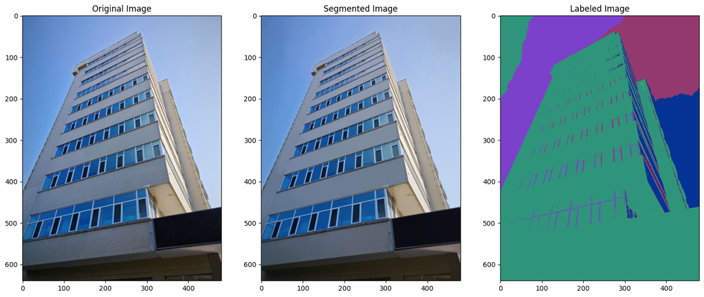

```python
import cv2
import numpy as np
import matplotlib.pyplot as plt
from utils.seg_viz import label_segments, color_labels

# 读取图像
image = cv2.imread('example.jpg')
image = cv2.cvtColor(image, cv2.COLOR_BGR2RGB)

# 均值移动参数
spatial_radius = 50 # 空间半径
color_radius = 10 # 颜色半径
max_pyramid_level = 1

# 应用均值移动分割
segmented_image = cv2.pyrMeanShiftFiltering(image, spatial_radius, color_radius, max_pyramid_level)

# 标记分割区域
num_labels, labels = label_segments(segmented_image, 5**3)
colored_labels = color_labels(labels)

# 显示结果
plt.figure(figsize=(18, 8))
plt.subplot(1, 3, 1)
plt.imshow(image)
plt.title('Original Image')
plt.subplot(1, 3, 2)
plt.imshow(segmented_image)
plt.title('Segmented Image')
plt.subplot(1, 3, 3)
plt.imshow(colored_labels)
plt.title('Labeled Image')
plt.show()
```